# Least Squares Linear Model Theory

Joseph Bolton

24 April, 2020

This page is a reference that I keep for myself, to refer to when fitting linear models.

```r
library(tidyverse)
library(mvtnorm)
```

Suppose that our data generating process is:

$$\begin{array}{lcl} \mathbf{y} &=&
\mathbf{X}\beta + \epsilon \\
\epsilon &{\sim}& \text{N}\Big(0 \space, \hspace{3mm} \sigma^2\mathbf{I}\Big)
\end{array}$$

$\mathbf{y}$ is an $n\times 1$ vector.

$\mathbf{X}$ is an $n\times p$ matrix.

$\epsilon$ is an $n\times 1$ vector.

$\epsilon$ is a random vector, and thus $\mathbf{y}$ is a random vector too (since its value is dependent on $\epsilon$).

$\mathbf{X}$ and $\beta$ are fixed (i.e. $\mathbf{X}$ and $\beta$ are the same in all datasets generated by this process).

This implies that random vector $\mathbf{y}$ has a multivariate normal distribution $\mathbf{y}\sim\text{N}\Big(\mathbf{X}\beta \space, \hspace{3mm} \sigma^2\mathbf{I}\Big)$

For a single given dataset $\{\mathbf{y},\mathbf{X}\}$, where outcome vector $\mathbf{y}$ and features/predictors $\mathbf{X}$ are known, we would want to estimate parameter/coefficient vector $\beta$.

The estimator $\hat \beta$ minimising the *sum of squared errors* $\epsilon'\epsilon=\sum_{i=1}^n\Big(\mathbf{y}-\underset{\hat{ \mathbf{y}}}{\underbrace{X \hat\beta}}\Big)^2$ for a given sample is $\hat \beta = (X'X)^{-1}X'\mathbf{y}$. This is called the *Ordinary Least Squares* (OLS) estimator.

The distribution of this estimator $\hat\beta$ across samples, under this data-generating process, is multivariate normal:

$$\hat\beta \quad\sim\quad \text{N}_p\Big(\beta \space, \hspace{3mm} \sigma^2 (X'X)^{-1}\Big)$$

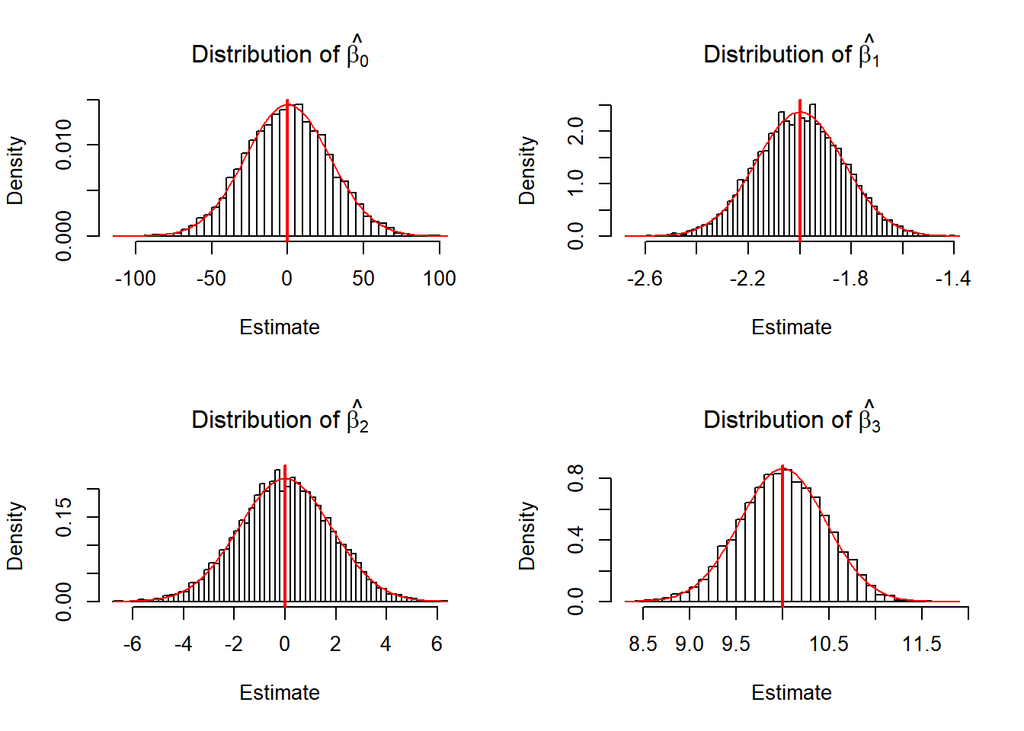

```r
set.seed(2)
# Define fixed parameters (the parameters that are the same for every dataset):
n <- 100
p <- 4
X <- cbind( intercept=1, x1=runif(n,-100,100), x2=rnorm(n,12,5), x3=rexp(n,rate=0.05) )
beta <- sample( -10:10, size=p ) * c(0,1,0,1)         # and make beta0 and beta2 zero
sigma <- 100

store_estimates <- matrix( rep(NA,4*10000), ncol=4 )       # create a matrix to store the ols_beta_hat estimates
colnames(store_estimates) <- c("b0", "b1", "b2", "b3")   # name columns of the matrix created above

for( i in 1:10000 ){      # run 10,000 simulations

  e <- rnorm(n, mean=0, sd=sigma)           # generate the errors
  y <- X %*% beta + e     # generate y
  ols_beta_hat <- solve( t(X)%*%X ) %*% t(X) %*% y    # calculate the OLS estimator of beta
  store_estimates[i,] <- ols_beta_hat                 # store the estimator
}

# plot the distributions of the beta OLS estimates generated in the simulation above:
par( mfrow=c(2,2) )
for( i in 1:4 ){
  hist(      x = store_estimates[,i],
        breaks = 50,
          main = bquote("Distribution of"~hat(beta[.(i-1)]) ),
          xlab = "Estimate",
          freq = FALSE
      )
  abline( v = beta[i], col=2, lwd=2 )
  curve( dnorm( x,
                mean = beta[i],
                  sd = sqrt(  (sigma^2) * solve( t(X)%*%X )[i,i]  )
              ),
         add = TRUE,
         col = 2
        )
}
```

If $\sigma^2$ were known, then this information could be used to generate confidence intervals for $\hat\beta$.

A confidence interval for a single coefficient $\beta_j$ is

$$\hat\beta_j \pm z(\displaystyle\frac{\alpha}{2})\cdot \sqrt{\Big[\sigma^2(X'X)^{-1}\Big]_{jj}}$$

..where $z(\displaystyle\frac{\alpha}{2})$ is the $1-\displaystyle\frac{\alpha}{2}$ quantile of the standard normal distribution.

In practice, since the true value of $\sigma^2$ is unknown, confidence intervals are generated using an estimate $\quad s^2=\hat{\sigma^2} \quad$ of $\sigma^2$, and the confidence interval is then:

$$\hat\beta_j \pm t_{n-p}(\displaystyle\frac{\alpha}{2})\cdot \sqrt{\Big[s^2(X'X)^{-1}\Big]_{jj}}$$

Rather than considering coefficients one at a time (which leads to more false positives/type 1 errors), it is possible to create simultaneous confidence regions for the parameters $\beta$. See [1] for details.

The estimated errors for a particular dataset are $\hat \epsilon = \underset{\hat{\mathbf{y}}}{\underbrace{X\hat\beta}} - \mathbf{y}$.

The expected value of $\hat\epsilon'\hat\epsilon$ across datasets is $E\Big[\hat\epsilon'\hat\epsilon\Big]=\sigma^2\Big(n-p\Big)$, which gives us an estimator

$$\hat{\sigma^2}=\displaystyle\frac{\hat\epsilon'\hat\epsilon}{n-p}$$

of $\sigma^2$, since

$$E\Big[\displaystyle\frac{\hat\epsilon'\hat\epsilon}{n-p}\Big]=\displaystyle\frac{1}{n-p}E\Big[\hat\epsilon'\hat\epsilon\Big]=\sigma^2$$

Here is an example of the distribution of $\hat{\sigma^2}$ across multiple datasets by simulation:

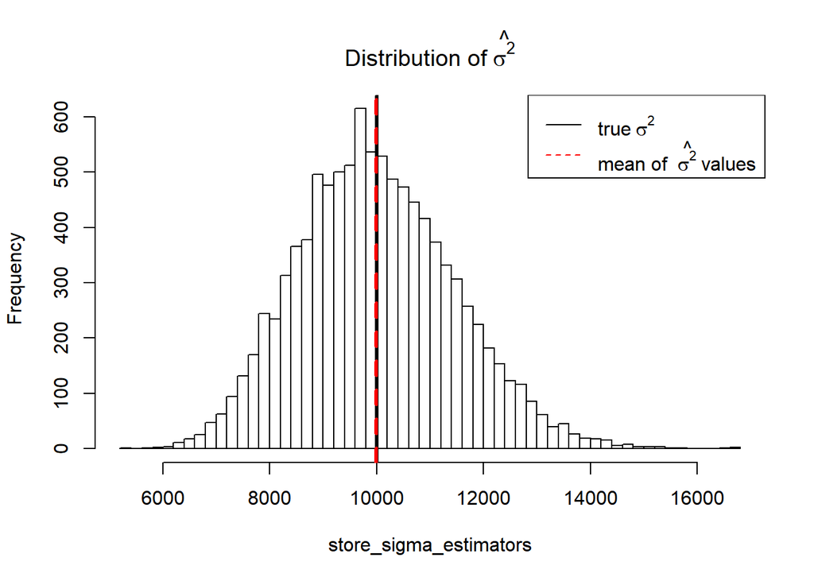

```r
set.seed(2)
# use the same values of [X] and [sigma] as the simulation above

store_sigma_estimators <- rep(NA,10000)       # create a vector to store sigma estimate from each sample

for( i in 1:10000 ){      # run 10,000 simulations

  e <- rnorm(n, mean=0, sd=sigma)                   # generate the errors
  y <- X %*% beta + e                               # generate y
  ols_beta_hat <- solve( t(X)%*%X ) %*% t(X) %*% y    # calculate the OLS estimator of beta
  y_hat <- X %*% ols_beta_hat                       # calculate the predicted values of y
  sample_errors <- y_hat - y                        # calculate the predicted errors for this dataset
  store_sigma_estimators[i] <- ( t(sample_errors)%*%sample_errors ) / (n-p)
}

hist(      x = store_sigma_estimators,
      breaks = 50,
        main = bquote("Distribution of"~hat(sigma^2) )
    )

# draw in true sigma^2 value:
abline( v = sigma^2, lwd=3 )
abline( v = mean(store_sigma_estimators), lwd=3, col=2, lty=2 )

# draw a legend on the plot:
legend( "topright",
        lty = c(1,2),
        col = c(1,2),
        legend = c( as.expression( bquote("true"~sigma^2) ) ,
                    as.expression( bquote("mean of "~hat(sigma^2)~"values") )
                  )
      )
```

In order to test the hypothesis $\beta_j=0$ (i.e. whether a particular coefficient $\beta_j$ is 0), we could use the result

$$\displaystyle\frac{\hat\beta_j}{\text{SE}\Big[\hat\beta_j\Big]} \quad=\quad \displaystyle\frac{\hat\beta_j}{\sqrt{\Big[\sigma^2(X^TX)^{-1}\Big]_{jj}}} \quad\sim\quad \text{N}\Big(0,1\Big)$$

However, not knowing $\sigma^2$, we can use the result

$$\begin{array}{lcl}
t_j &=& \displaystyle\frac{\hat\beta_j}{\hat{\text{SE}}\Big[\hat\beta_j\Big]} \quad=\quad \displaystyle\frac{\hat\beta_j}{\sqrt{\Big[s^2(X^TX)^{-1}\Big]_{jj}}} \\
t_j &\sim& \text{t}_{n-p} \quad \text{ if the null hypothesis } (H_0:\beta_j=0) \text{ is true} \end{array}$$

i.e. $t_j$ has a $t$-distribution with $n-p$ degress of freedom under the null hypothesis.

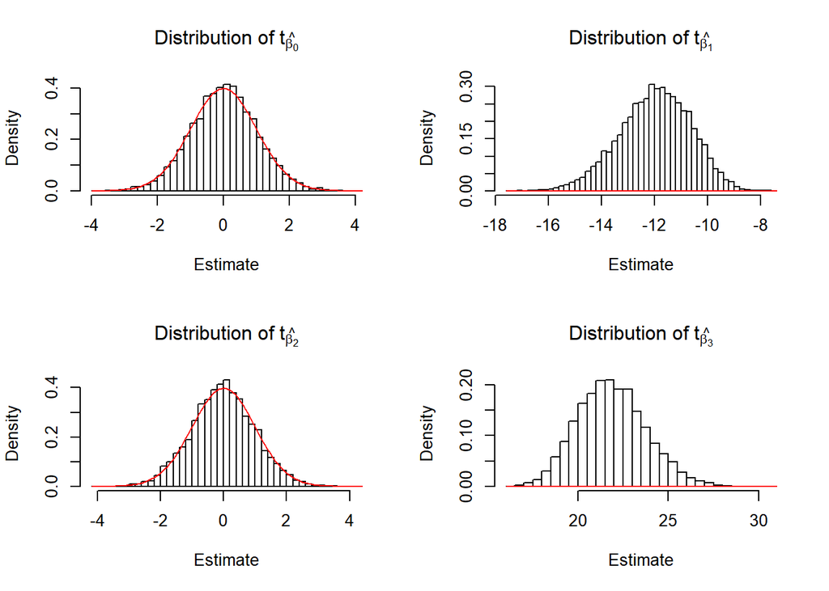

```r
set.seed(2)
store_estimates <- matrix( rep(NA,4*10000), ncol=4 )       # create a matrix to store the ols_beta_hat estimates
colnames(store_estimates) <- c("t_b0", "t_b1", "t_b2", "t_b3")   # name columns of the matrix created above

for( i in 1:10000 ){      # run 10,000 simulations

  e <- rnorm(n, mean=0, sd=sigma)           # generate the errors
  y <- c(  X %*% beta + e  )                        # generate y
  cov_beta_hat <- sigma^2 * solve( t(X)%*%X )   # calculate the variance/covariance matrix of beta_hat estimators
  ols_beta_hat <- c(  solve( t(X)%*%X ) %*% t(X) %*% y  )    # calculate the OLS estimator of beta
  y_hat <- c(  X %*% ols_beta_hat  )                        # calculate the fitted values of y
  sigma2_est <- c( t(y_hat-y)%*%(y_hat-y) ) / (n-p)          # generate estimate of sigma^2
  store_estimates[i,] <- c(ols_beta_hat) / sqrt( sigma2_est * diag(solve( t(X)%*%X )) )    # store the t-statistics
}

# plot the distributions of the t statistics generated in the simulation above:
par( mfrow=c(2,2) )
for( i in 1:4 ){
  hist(      x = store_estimates[,i],
        breaks = 50,
          main = bquote("Distribution of"~t[hat(beta[.(i-1)])] ),
          xlab = "Estimate",
          freq = FALSE
      )
  curve( dt( x,
             df = n-p
            ),
         add = TRUE,
         col = 2
       )
}
```

Note that $p$-values become smaller when sample size increases, making hypothesis tests based on $p$-values simply a function of sample size. Confidence intervals for effect sizes are preferred.

# When to consider estimators of $\beta$ other than OLS

From reference [1]:

1. If errors are correlated or have unequal variance ($\sigma^2$ is not constant across samples 1,..,n), then *Generalized Least Squares* should be used to estimate $\hat \beta$.
2. If the error distribution is long-tailed, then *robust estimators* of $\hat \beta$ should be considered.
3. When the features/predictors are highly correlated (collinear), then penalised (biased) estimators should be considered (e.g. Ridge regression, Lasso).

# Generalized Least Squares (GLS)

Suppose that our data generating process is:

$$\begin{array}{lcl} \mathbf{y} &=&
\mathbf{X}\beta + \epsilon \\
\epsilon &{\sim}& \text{N}\Big(0 \space, \hspace{3mm} \sigma^2\Sigma\Big)
\end{array}$$

$\mathbf{y}$ is an $n\times 1$ vector.

$\mathbf{X}$ is an $n\times p$ matrix.

$\epsilon$ is an $n\times 1$ vector.

$\epsilon$ is a random vector, and thus $\mathbf{y}$ is a random vector too (since its value is dependent on $\epsilon$).

$\mathbf{X}$ and $\beta$ are fixed (i.e. $\mathbf{X}$ and $\beta$ are the same in all datasets generated by this process).

The constant $\sigma^2$ (absolute scale of the errors) is unknown, but the covariance structure (matrix $\Sigma$) of the errors is known [1].

This implies that random vector $\mathbf{y}$ has a multivariate normal distribution $\mathbf{y}\sim\text{N}\Big(\mathbf{X}\beta \space, \hspace{3mm} \sigma^2\Sigma\Big)$

For a single given dataset $\{\mathbf{y},\mathbf{X}\}$, where outcome vector $\mathbf{y}$ and features/predictors $\mathbf{X}$ are known, we would want to estimate parameter/coefficient vector $\beta$.

The estimator $\hat \beta$ minimising $(\mathbf{y}-\mathbf{X}\beta)'\Sigma^{-1}(\mathbf{y}-\mathbf{X}\beta)$ for a given sample is:

$$\hat \beta = (X'\Sigma^{-1}X)^{-1}X'\Sigma^{-1}\mathbf{y}$$

$(\mathbf{y}-\mathbf{X}\beta)'\Sigma^{-1}(\mathbf{y}-\mathbf{X}\beta)$ is the squared *Mahalanobis* distance between vector $\mathbf{y}$ and vector $\hat{\mathbf{y}}$.

The variance of this estimator $\hat\beta$ across samples, under this data-generating process, is $\sigma^2 (X'\Sigma^{-1} X)^{-1}$:

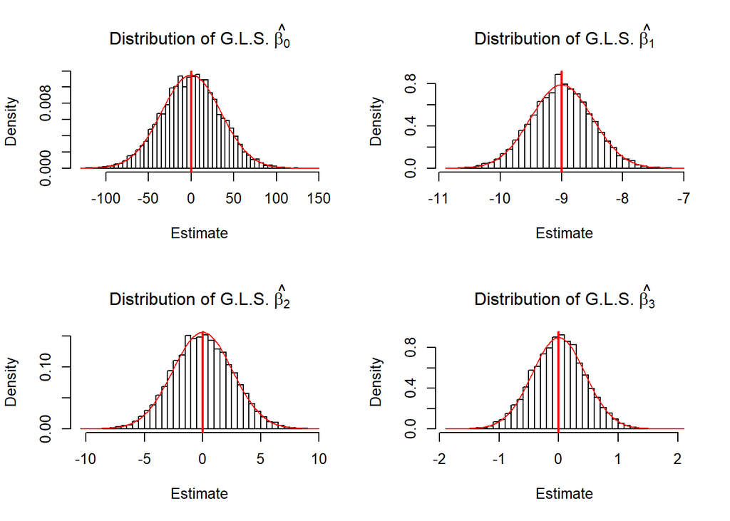

```r
set.seed(2)
# Define fixed parameters (the parameters that are the same for every dataset):
n <- 50
p <- 4
X <- cbind( intercept=1, x1=runif(n,-100,100), x2=rnorm(n,12,5), x3=rexp(n,rate=0.05) )
beta <- sample( -10:10, size=p ) * c(0,1,0,1)         # and make beta0 and beta2 zero
sigma <- 10

# generate random variance/covariance structure for errors:
tempmat <- matrix( runif(n*n,-10,10), n, n )
sigma_covmat <- round( t(tempmat) %*% tempmat )

store_estimates <- matrix( rep(NA,4*10000), ncol=4 )       # create a matrix to store the beta_hat estimates
colnames(store_estimates) <- c("b0", "b1", "b2", "b3")   # name columns of the matrix created above

for( i in 1:10000 ){      # run 10,000 simulations
  e <- mvtnorm::rmvnorm(     n = 1,        # generate the errors
                          mean = rep(0, n),
                         sigma = sigma^2 * sigma_covmat
                       ) %>% t()
  y <- X %*% beta + e     # generate y

  # calculate the GLS estimator of beta:
  estimate_beta_hat <- solve( t(X)%*%solve(sigma_covmat)%*%X ) %*% t(X) %*% solve(sigma_covmat) %*% y
  store_estimates[i,] <- estimate_beta_hat                 # store the GLS estimator
}


# plot the distributions of the beta estimates generated in the simulation above:
par( mfrow=c(2,2) )
for( i in 1:4 ){
  hist(      x = store_estimates[,i],
        breaks = 50,
          main = bquote("Distribution of G.L.S."~hat(beta[.(i-1)]) ),
          xlab = "Estimate",
          freq = FALSE
      )
  abline( v = beta[i], col=2, lwd=2 )
  curve( dnorm( x,
                mean = beta[i],
                  sd = sqrt(  (sigma^2) * solve( t(X)%*%solve(sigma_covmat)%*%X )[i,i]  )
              ),
         add = TRUE,
         col = 2
        )
}
```

Of course, matrix $\Sigma$ will not be known in practice and must be estimated.

# Weighted Least Squares (WLS)

If some observations are more important than others, then **Weighted Least Squares** (**WLS**) can be used to estimate the coefficients $\beta$ in the model.

Parameter estimates $\hat{\beta}$ are now found by choosing the vector $\hat\beta$ which minimises:

$$\mathcal{L}(\hat\beta)=\displaystyle\sum_{i=1}^n w_i \cdot \Big(y_i - \mathbf{x}_i'\beta\Big)^2$$

..where $w_i$ is the weight on observation $i$.

This gives the following estimate of $\hat\beta$:

$$\hat\beta \quad=\quad \Big(X' W X\Big)^{-1} X' W y$$

where

$$W=\begin{bmatrix} w_1 & 0 & 0 & ... & 0 \\
0 & w_2& 0 & ... & 0 \\
. & . & . & ... & . \\
. & . & . & ... & . \\
0 & 0 & 0 & ... & w_n \\
\end{bmatrix}$$

**WLS** is usually used in the situation where the errors $\epsilon$ in the model are uncorrelated but heteroskedastic (error variance for each observation is different):

$$\begin{array}{lcl} \mathbf{y} &=&
\mathbf{X}\beta + \epsilon \\
\epsilon &{\sim}& \text{N}\Big(0 \space, \hspace{3mm} \Sigma=\begin{bmatrix}\sigma_1^2 &0 & 0 & ...& 0 \\
0 & \sigma_2^2 & 0 & ... & 0 \\
. & .& . & ... & . \\
. & .& . & ... & . \\
0 & 0& 0 & ... & \sigma_n^2 \\
\end{bmatrix}\Big)
\end{array}$$

In this case, the weight chosen for each observation is $w_i=\displaystyle\frac{1}{\sigma_i^2}$.

Weighted regression calculated in this way is equivalent to performing standard **OLS** regression on a dataset in which each sample/observation $i=1,..,n$ has been duplicated a number of times proportional to it’s weight $w_i$.

```r
# simulate some random data:
mydata <- tibble( x1 = rnorm(100), x2=runif(100), x3=sample(0:1,size=100,replace=TRUE) )

true_beta <- sample(-10:10, size=4)
mydata <- mydata %>%
            mutate( error = rnorm(n()) ) %>%
            mutate( y = true_beta[1] + true_beta[2]*x1 + true_beta[3]*x2 + true_beta[4]*x3 + error ) %>%
            mutate( weight = sample(1:5, size=n(), replace=TRUE) )
mydata
```

| x1 | x2 | x3 | error | y | weight |
| --- | --- | --- | --- | --- | --- |
| 0.55314032 | 0.7940924780 | 0 | 0.14237720 | -9.3594884 | 2 |
| -0.52467432 | 0.5708875475 | 0 | 1.59882797 | 3.9911334 | 2 |
| -0.96534323 | 0.2586586853 | 1 | 1.52269243 | 8.8828313 | 4 |
| 0.64446254 | 0.9281724470 | 0 | -1.03669719 | -12.1221848 | 1 |
| -2.03817752 | 0.2111950056 | 0 | 0.21211847 | 19.5379187 | 2 |
| 1.56940204 | 0.7446510224 | 1 | -0.89942715 | -21.3167027 | 3 |
| 0.63778310 | 0.6054445745 | 0 | 2.58097411 | -6.8240798 | 1 |
| 1.23450980 | 0.8848225344 | 1 | 0.24532697 | -17.5238838 | 4 |
| -1.11790969 | 0.8453248655 | 0 | -0.58437491 | 6.3680976 | 5 |
| 0.70516806 | 0.4083214817 | 1 | 2.61870589 | -7.4745821 | 4 |

[output cut: 90 more lines]

```r
X <- cbind(1,mydata[,c("x1","x2","x3")]) %>% as.matrix()
y <- mydata$y
W <- diag(mydata$weight)

# create an augmented dataset by duplicating each row/sample/observation according to it's weight:
mydata_5col <- mydata %>% select(y,x1,x2,x3) %>% mutate(rownum = row_number())
augmented_dataset <- mydata_5col %>% slice(0)
for( row_i in 1:nrow(mydata) ){

  for( j in 1:mydata$weight[row_i] ){
    augmented_dataset <- bind_rows( augmented_dataset,
                                    mydata_5col[row_i,]
                                  )
  }
}

# three equivalent methods, all leading to the same result:
lm( y ~ x1 + x2 + x3, data=augmented_dataset )
```

```
##
## Call:
## lm(formula = y ~ x1 + x2 + x3, data = augmented_dataset)
##
## Coefficients:
## (Intercept)           x1           x2           x3
##      0.3346     -10.0615      -5.6777      -1.1734
```

```r
lm( y ~ x1+x2+x3, data=mydata, weights=mydata$weight )
```

```
##
## Call:
## lm(formula = y ~ x1 + x2 + x3, data = mydata, weights = mydata$weight)
##
## Coefficients:
## (Intercept)           x1           x2           x3
##      0.3346     -10.0615      -5.6777      -1.1734
```

```r
solve( t(X) %*% W %*% X ) %*% t(X) %*% W %*% y
```

```
##           [,1]
## 1    0.3345705
## x1 -10.0615104
## x2  -5.6777383
## x3  -1.1734282
```

# References

1. https://cran.r-project.org/doc/contrib/Faraway-PRA.pdf